# SwitftRKey: A typing prediction app written in R

Marcio Gualtieri (marcio dot gualtieri at gmail dot com)

## Installing Dependencies

You will need to install some libraries in your operating system before you install the required packages.

### WordNet

Follow the instructions for Linux:

```
sudo apt-get install wordnet
```

### LibV8

Follow the instructions for Linux:

```
sudo apt-get install libv8-dev
```

This library is required by the [pluralize package](https://github.com/hrbrmstr/pluralize).

## Installing the Required Packages

You might need to install the following packages if you don’t already have them:

```r
install.packages("dplyr")
install.packages("R.utils")
install.packages("tm")
install.packages("wordcloud")
install.packages("SnowballC")
install.packages("ggplot2")
install.packages("codetools")
install.packages("RWeka")
install.packages("textcat")
install.packages("ff")
install.packages("bigmemory", repos = "http://R-Forge.R-project.org")
install.packages("qdap")
install.packages("textcat")
install.packages("data.table")
install.packages("wordnet")
install.packages("pacman")
install.packages("markovchain")
install.packages("R.cache")
```

Just run the commands for the packages you need or run the whole chunk before you run the remaining ones in this notebook.

## Importing the Required Packages

Once the libraries are installed, they need to be loaded as follows:

```r
suppressMessages(library(dplyr))
suppressMessages(library(plyr))
suppressMessages(library(R.utils))
suppressMessages(library(tm))
suppressMessages(library(wordcloud))
suppressMessages(library(SnowballC))
suppressMessages(library(ggplot2))
suppressMessages(library(RWeka))
suppressMessages(library(textcat))
suppressMessages(library(ff))
suppressMessages(library(bigmemory))
suppressMessages(library(qdap))
suppressMessages(library(textcat))
suppressMessages(library(data.table))
suppressMessages(library(wordnet))
suppressMessages(library(pacman))
p_load_gh('hrbrmstr/pluralize')
p_load(quanteda)
suppressMessages(library(markovchain))
suppressMessages(library(R.cache))
```

Wordnet also requires the following setup (Linux):

```r
Sys.setenv(WNHOME = "/usr/bin/wordnet")
wordnet_path <- file.path("usr", "share", "dict")
setDict(wordnet_path)
```

## Knitr Settings

The raw data-set is pretty big, which might make rendering the output slow, so let’s enable knitr’s global caching:

```r
knitr::opts_chunk$set(cache = TRUE)
```

I’m also enabling verbose for easier debugging:

```r
knitr::opts_knit$set(verbose = TRUE)
```

## Setting a Seed

To make sure this notebook is reproducible:

```r
set.seed(123)
```

## Synopsis

The objectives of this notebook are basic data cleaning, exploratory data analysis and model design and generation for a keyboard typing predicting app, i.e., capable of predicting what’s the next word given the currently typed words.

We are going to start by using some of R’s text-mining packages to find some basic patterns in a corpus of English text, e.g., what’s the distribution of words, what are the relationships between words in sentences, etc.

Our work-horse is going to be the [tm](http://tm.r-forge.r-project.org/) package, but we are also relying on some other auxiliary packages to get the job done, such as:

- [RWeka](https://www.rdocumentation.org/packages/RWeka/versions/0.4-34)
- [wordcloud](https://www.rdocumentation.org/packages/wordcloud/versions/2.5)
- [textcat](https://www.rdocumentation.org/packages/textcat/versions/1.0-4)
- qdap

The final prediction model consists of a transition matrix (which represents a [Markov process](https://en.wikipedia.org/wiki/Markov_chain)) that can be easily imported into a R app or notebook.

## Data Processing

### Downloading the Data-set

There seem to be three different categories of text (“blogs”, “news” and “twitter”) for four different languages (German, English, finnish and Russian).

Here’s a sample from “blogs”:

```r
file_head <- function(name, n = 3) {
    connection <- file(name, open = "r")
    result <- readLines(connection, n = n)
    close(connection)
    result
}

file_head("./data/final/en_US/en_US.blogs.txt")
```

```
## [1] "In the years thereafter, most of the Oil fields and platforms were named after pagan “gods”."
## [2] "We love you Mr. Brown."
## [3] "Chad has been awesome with the kids and holding down the fort while I work later than usual! The kids have been busy together playing Skylander on the XBox together, after Kyan cashed in his $$$ from his piggy bank. He wanted that game so bad and used his gift card from his birthday he has b…
```

A sample from “news”:

```r
file_head("./data/final/en_US/en_US.news.txt")
```

```
## [1] "He wasn't home alone, apparently."
## [2] "The St. Louis plant had to close. It would die of old age. Workers had been making cars there since the onset of mass automotive production in the 1920s."
## [3] "WSU's plans quickly became a hot topic on local online sites. Though most people applauded plans for the new biomedical center, many deplored the potential loss of the building."
```

A sample from “twitter”:

```r
file_head("./data/final/en_US/en_US.twitter.txt")
```

```
## [1] "How are you? Btw thanks for the RT. You gonna be in DC anytime soon? Love to see you. Been way, way too long."
## [2] "When you meet someone special... you'll know. Your heart will beat more rapidly and you'll smile for no reason."
## [3] "they've decided its more fun if I don't."
```

Helps to get some basic metadata on the files we are working with:

```r
file_size <- function(name)
    suppressWarnings(utils:::format.object_size(file.info(name)[["size"]], "auto"))

file_lines <- function(name)
    suppressWarnings(countLines(name))

longest_line <- function(name)
    suppressWarnings(max(sapply(readLines(name), nchar)))

files_info <- function(dir) {
    files <- list.files(dir, recursive = TRUE, full.names = TRUE)
    data.frame(size = sapply(files, file_size),
               lines = sapply(files, file_lines),
               longest_line = sapply(files, longest_line))
}

files_info("./data/final/en_US")
```

|  | size | lines | longest_line |
| --- | --- | --- | --- |
| ./data/final/en_US/en_US.blogs.txt | 200.4 Mb | 899288 | 40833 |
| ./data/final/en_US/en_US.news.txt | 196.3 Mb | 1010242 | 11384 |
| ./data/final/en_US/en_US.twitter.txt | 159.4 Mb | 2360148 | 140 |

For purposes of exploratory data analysis and modeling, we are going to use only the English corpus.

### Sampling from the Input Files

As we have found out in the previous section, the files are huge, thus we are going to work with a sub-set from the available data. The following code is going to take random samples from the available text files:

```r
sample_file <- function(input_file, sample_fraction, test_fraction) {
    connection <- file(input_file, open = "r")
    lines <- readLines(connection, skipNul = TRUE)
    number_lines <- length(lines)
    close(connection)
    sample_indexes <- sample(1:number_lines, as.integer(number_lines * sample_fraction), replace = FALSE)
    partitioning_index <- as.integer(length(sample_indexes) * (1 - test_fraction))
    list(
        lines[sample_indexes[1:partitioning_index]],
        lines[sample_indexes[(partitioning_index + 1):length(sample_indexes)]]
    )
}

create_sample_file <- function(input_file, output_dir, sample_fraction, test_fraction) {
    sample <- sample_file(input_file, sample_fraction, test_fraction)
    train_sample <- sample[[1]]
    test_sample <- sample[[2]]
    dir.create(paste0(output_dir, "/training"), recursive = TRUE, showWarnings = FALSE)
    dir.create(paste0(output_dir, "/testing"), recursive = TRUE, showWarnings = FALSE)
    writeLines(train_sample, paste0(output_dir, "/training/", basename(input_file)))
    writeLines(test_sample, paste0(output_dir, "/testing/", basename(input_file)))
}

create_sample_files <- function(input_dir, output_dir, sample_fraction, test_fraction) {
     files <- list.files(input_dir, recursive = TRUE, full.names = TRUE)
     invisible(sapply(files, create_sample_file, output_dir = output_dir,
                      sample_fraction = sample_fraction,
                      test_fraction = test_fraction))
}

create_sample_files("./data/final/en_US", "./data/samples", 0.001, 0.3)
```

We are going to take 0.1% of the sentences inside each file in the directory. I have verified by trial and error that this amount is sufficient to see the patterns we need to see.

### Text-Mining

#### Create Corpus

The first step is creating a corpus of text from the raw data:

```r
corpus <- VCorpus(DirSource("./data/samples/training"), readerControl = list(language = "en_US"))
```

#### Cleanup Corpus

We are required to remove some unwanted symbols from the text now (white space, punctuation, numbers, etc). We are also going to transform every words to lowercase and remove stop words:

```r
replacePunctuation <- content_transformer(function(x) gsub("[^[:alnum:][:space:]'`]", " ", x))

clean_corpus <- function(corpus) {
    corpus <- tm_map(corpus, stripWhitespace)
    corpus <- tm_map(corpus, replacePunctuation)
    corpus <- tm_map(corpus, removeNumbers)
    corpus <- tm_map(corpus, content_transformer(tolower))
    corpus
}

corpus <- clean_corpus(corpus)
```

I’m not using tm’s default `removePunctuation()` though, because it would remove apostrophes, e.g., “we’re” would become “were”.

Contractions are not single words: e.g., “we’re” and “doesn’t” are actually “we are” and “does not”. Thus, apostrophes should be considered delimiter characters (like whitespaces).

Also note that I’m not removing stop words. In general, if we were working with feature extraction (for machine learning), we would do that, but given that stop words are relevant for predicting text typing in natural languages, we must keep them.

#### Stemming

I’m not so sure at this moment that I should be doing stemming. I’m leaving the command here for now for future reference (evaluation for this chunk is turned off).

```r
corpus <- tm_map(corpus, stemDocument, language = "english")
```

#### Remove Curse Words

The most legitimate source for curse words I could find is [this project on GitHub](https://github.com/LDNOOBW/List-of-Dirty-Naughty-Obscene-and-Otherwise-Bad-Words). This project maintains lists of curse words in several languages, including the ones we require for our data-sets.

```r
load_curse_words <- function(curse_words_url) {
    connection <- url(curse_words_url)
    lines <- readLines(connection)
    close(connection)
    lines
}

curse_words <- load_curse_words(
    "https://raw.githubusercontent.com/LDNOOBW/List-of-Dirty-Naughty-Obscene-and-Otherwise-Bad-Words/master/en"
    )

corpus_without_curse_words <- tm_map(corpus, removeWords, curse_words)
```

I’m going to extract the corpus generation code to a function for easier use:

```r
create_corpus <- function(data_dir) {
  corpus <- VCorpus(DirSource(data_dir), readerControl = list(language = "en_US"))
  corpus <- clean_corpus(corpus)
  tm_map(corpus, removeWords, curse_words)
}
```

I’m going to resample a larger fraction of the data later for use in the prediction model generation.

## Exploratory Data Analysis

### Distribution of N-Grams of Size from One to Four Words

```r
create_ngrams_data_frame <- function(document_term_matrix) {
  frequencies <- colSums(document_term_matrix)
  ngrams <- data.frame(ngram = names(frequencies), frequency = frequencies, stringsAsFactors = FALSE)
  ngrams <- arrange(ngrams, desc(frequency))
  rownames(ngrams) <- 1:length(frequencies)
  return(ngrams)
}

one_gram_tokenizer <- function(x)
  NGramTokenizer(x, Weka_control(min = 1, max = 1))

document_term_matrix <- DocumentTermMatrix(corpus_without_curse_words,
                                           control = list(tokenize = one_gram_tokenizer,
                                                          wordLengths=c(1, Inf)))

one_grams <- create_ngrams_data_frame(as.matrix(document_term_matrix))
top_one_grams <- one_grams[1:50, ]
top_one_grams
```

| ngram | frequency |
| --- | --- |
| the | 3392 |
| to | 1877 |
| and | 1698 |
| a | 1571 |
| i | 1431 |
| of | 1386 |
| in | 1164 |
| s | 826 |
| it | 804 |
| for | 775 |
| that | 759 |
| is | 727 |
| you | 723 |
| on | 583 |
| with | 504 |
| was | 459 |
| my | 421 |
| this | 420 |
| at | 410 |
| he | 380 |
| be | 374 |
| t | 358 |
| but | 355 |
| have | 335 |
| we | 327 |
| as | 318 |
| are | 294 |
| not | 275 |
| so | 274 |
| me | 271 |
| from | 258 |
| his | 248 |
| all | 235 |
| will | 233 |
| an | 224 |
| by | 223 |
| what | 219 |
| up | 213 |
| just | 212 |
| said | 212 |
| one | 210 |
| about | 207 |
| they | 207 |
| can | 206 |
| or | 200 |
| like | 197 |
| out | 185 |
| your | 185 |
| if | 180 |
| m | 179 |

Here’s a bar chart for the top words in the distribution:

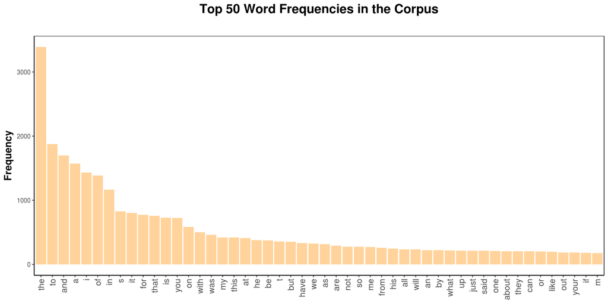

```r
ngram_frequency_barchart <-function(ngrams)
    ggplot(ngrams, aes(x = ngram, y = frequency)) +
        geom_bar(stat="identity", fill = "burlywood1") +
        scale_x_discrete(limits = ngrams$ngram) +
        ggtitle(paste("Top", nrow(ngrams), "Word Frequencies in the Corpus")) +
        ylab("Frequency") +
        theme(axis.text.x = element_text(size = 12, angle = 90, hjust = 1, vjust = 0.5)) +
        theme(plot.title = element_text(size = 18, face = "bold",
                                        hjust = 0.5, margin = margin(b = 30, unit = "pt"))) +
        theme(axis.title.x = element_blank()) +
        theme(axis.title.y = element_text(size = 14, face="bold")) +
        theme(panel.background = element_blank(), axis.line = element_line(colour = "black")) +
        theme(panel.border = element_rect(colour = "black", fill = NA, size = 0.5)) +
        theme(strip.background = element_rect(fill = alpha("burlywood3", 0.3), color = "black", size = 0.5)) +
        theme(legend.title = element_blank())

ngram_frequency_barchart(top_one_grams)
```

A word cloud is also a good visualization tool for n-gram frequency:

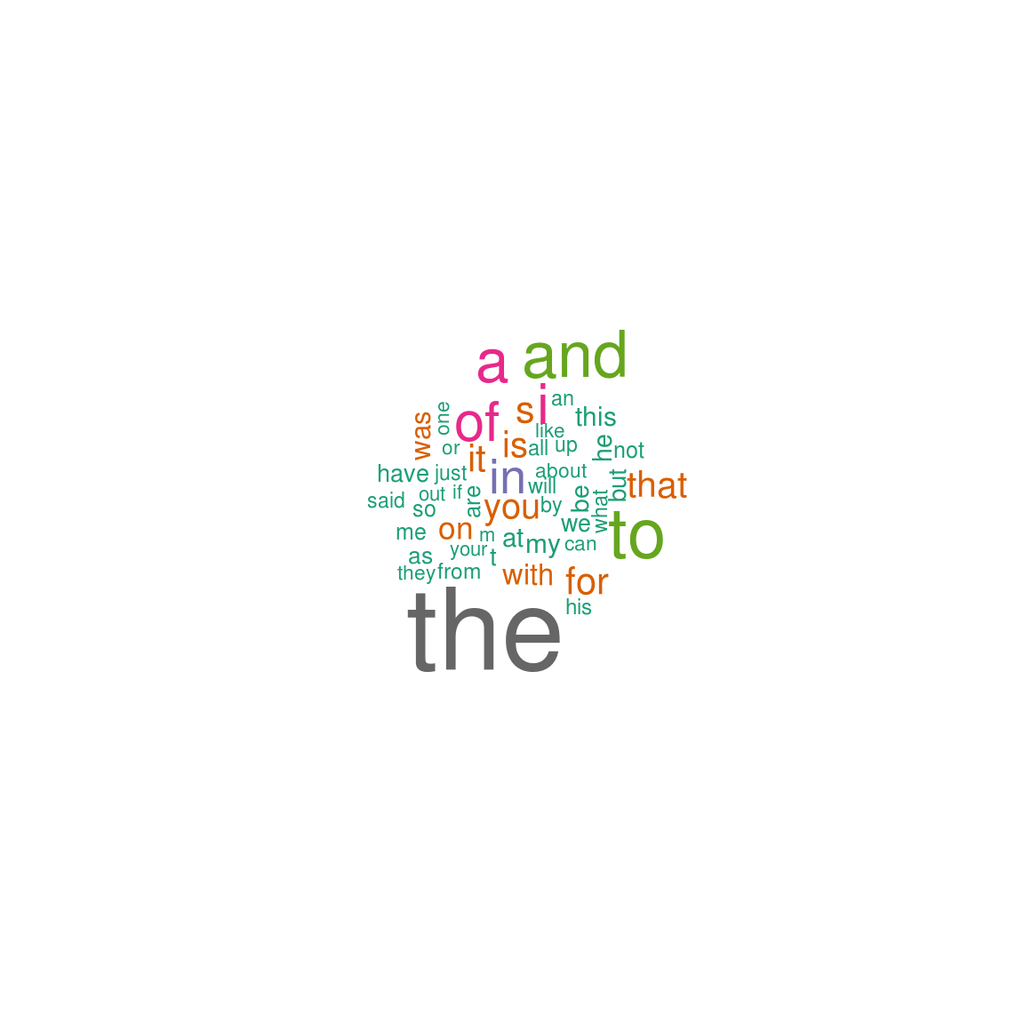

```r
words_cloud <- function(ngrams)
    wordcloud(ngrams$ngram, ngrams$frequency, scale = c(4, 0.5), colors = brewer.pal(8, "Dark2"))

words_cloud(top_one_grams)
```

### Distribution of N-Grams of Size Two Words

```r
two_ngram_tokenizer <- function(x)
  NGramTokenizer(x, Weka_control(min = 2, max = 2))

document_term_matrix <- DocumentTermMatrix(corpus_without_curse_words,
                                           control = list(tokenize = two_ngram_tokenizer,
                                                          wordLengths=c(1, Inf)))

two_ngrams <- create_ngrams_data_frame(as.matrix(document_term_matrix))

top_two_ngrams <- two_ngrams[1:50, ]
top_two_ngrams
```

| ngram | frequency |
| --- | --- |
| of the | 321 |
| in the | 291 |
| it s | 185 |
| for the | 162 |
| on the | 149 |
| i m | 147 |
| to the | 144 |
| don t | 106 |
| to be | 106 |
| and the | 91 |
| and i | 90 |
| is a | 76 |
| at the | 73 |
| i am | 71 |
| with the | 71 |
| i was | 70 |
| in a | 68 |
| will be | 67 |
| from the | 64 |
| that s | 62 |
| but i | 61 |
| for a | 61 |
| want to | 61 |
| it was | 60 |
| i have | 58 |
| can t | 57 |
| as a | 54 |
| going to | 53 |
| to see | 53 |
| have a | 51 |
| it is | 51 |
| one of | 50 |
| this is | 50 |
| is the | 47 |
| of a | 47 |
| s a | 47 |
| and a | 46 |
| i can | 46 |
| was a | 45 |
| with a | 45 |
| didn t | 44 |
| to get | 44 |
| a lot | 43 |
| by the | 43 |
| have to | 43 |
| i ve | 42 |
| if you | 41 |
| i don | 40 |
| thanks for | 40 |
| that the | 40 |

Its bar chart:

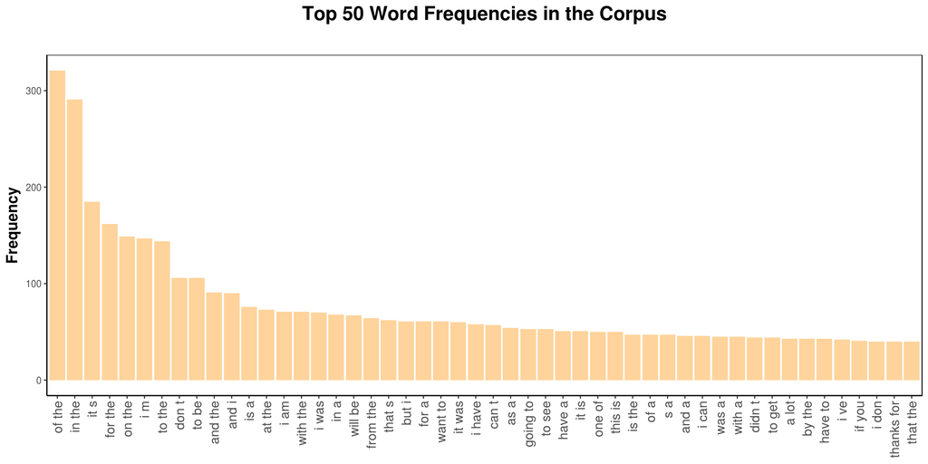

```r
ngram_frequency_barchart(top_two_ngrams)
```

Its word cloud:

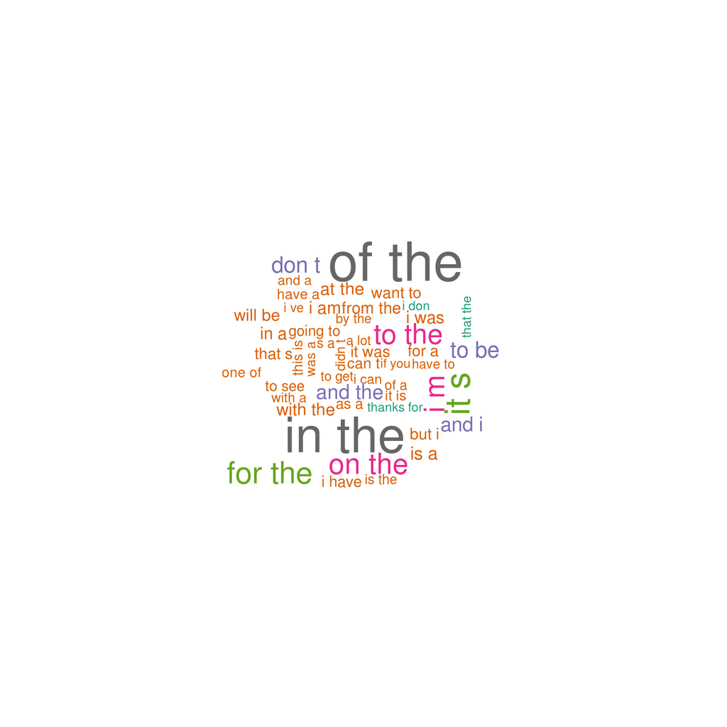

```r
words_cloud(top_two_ngrams)
```

### Distribution of N-Grams of Size Three Words

```r
three_ngram_tokenizer <- function(x)
  NGramTokenizer(x, Weka_control(min = 3, max = 3))

document_term_matrix <- DocumentTermMatrix(corpus_without_curse_words,
                                           control = list(tokenize = three_ngram_tokenizer,
                                                          wordLengths=c(1, Inf)))

three_ngrams <- create_ngrams_data_frame(as.matrix(document_term_matrix))

top_three_ngrams <- three_ngrams[1:50, ]
top_three_ngrams
```

| ngram | frequency |
| --- | --- |
| i don t | 40 |
| one of the | 30 |
| a lot of | 28 |
| it s a | 27 |
| i can t | 23 |
| thanks for the | 19 |
| can t wait | 18 |
| going to be | 18 |
| i didn t | 17 |
| to be a | 17 |
| i m not | 16 |
| as well as | 15 |
| i want to | 15 |
| don t know | 14 |
| it s not | 14 |
| it was a | 13 |
| t want to | 13 |
| and i m | 12 |
| some of the | 12 |
| in the world | 11 |
| part of the | 11 |
| the end of | 11 |
| t wait to | 11 |
| you don t | 11 |
| is going to | 10 |
| it would be | 10 |
| out of the | 10 |
| thank you for | 10 |
| this is a | 10 |
| and it s | 9 |
| be able to | 9 |
| don t have | 9 |
| he didn t | 9 |
| i think i | 9 |
| i wanted to | 9 |
| s going to | 9 |
| that s what | 9 |
| the fact that | 9 |
| to see the | 9 |
| you want to | 9 |
| according to the | 8 |
| but it s | 8 |
| don t want | 8 |
| do you think | 8 |
| i am not | 8 |
| in the s | 8 |
| the city s | 8 |
| the state s | 8 |
| the u s | 8 |
| all of the | 7 |

Its bar chart:

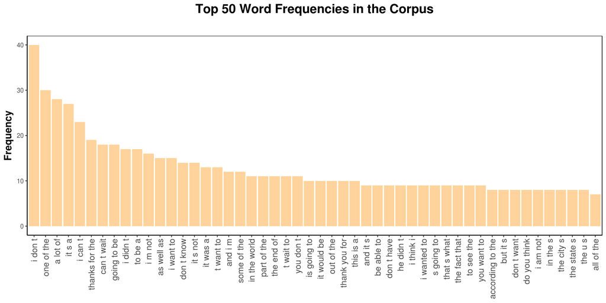

```r
ngram_frequency_barchart(top_three_ngrams)
```

Its word cloud:

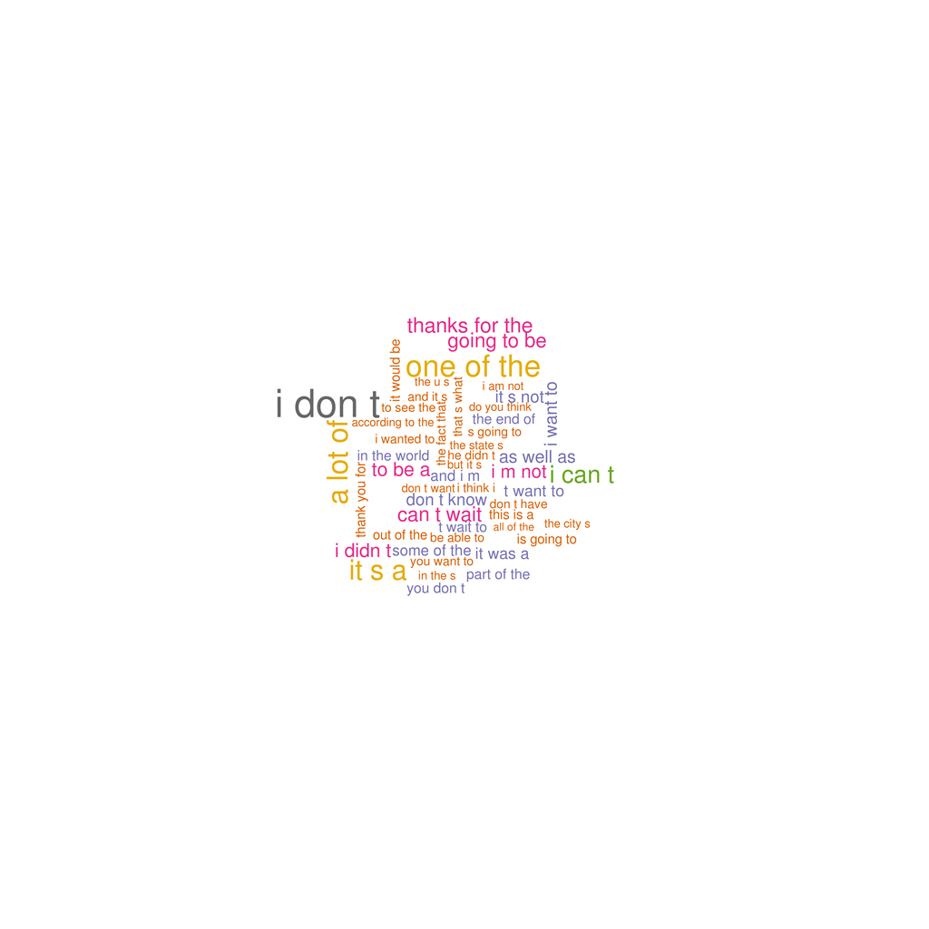

```r
words_cloud(top_three_ngrams)
```

You are going to need N-Grams with size 4 as well for the model, but I’m not going to plot their frequencies:

```r
four_gram_tokenizer <- function(x)
  NGramTokenizer(x, Weka_control(min = 4, max = 4))

document_term_matrix <- DocumentTermMatrix(corpus_without_curse_words,
                                           control = list(tokenize = four_gram_tokenizer,
                                                          wordLengths=c(1, Inf)))

four_ngrams <- create_ngrams_data_frame(as.matrix(document_term_matrix))
four_ngrams[1: 50, ]
```

| ngram | frequency |
| --- | --- |
| can t wait to | 11 |
| i don t know | 9 |
| don t want to | 7 |
| i can t wait | 7 |
| s going to be | 7 |
| thanks for the follow | 7 |
| going to be a | 6 |
| i don t think | 6 |
| it s going to | 6 |
| hope to see you | 5 |
| i don t want | 5 |
| is going to be | 5 |
| one of the best | 5 |
| t wait to see | 5 |
| at the end of | 4 |
| didn t have to | 4 |
| do not want to | 4 |
| don t have a | 4 |
| i don t have | 4 |
| if you want to | 4 |
| in the middle of | 4 |
| over and over again | 4 |
| pharmacist jobs north dakota | 4 |
| thank you for the | 4 |
| the children of israel | 4 |
| the end of the | 4 |
| the pharmacist jobs north | 4 |
| the rest of the | 4 |
| the sheriff s office | 4 |
| to be in the | 4 |
| what s going on | 4 |
| a lot of people | 3 |
| a member of the | 3 |
| and a lot of | 3 |
| and around and around | 3 |
| and i can t | 3 |
| and i don t | 3 |
| and i m not | 3 |
| around and around and | 3 |
| boss of me now | 3 |
| but i can t | 3 |
| but it s not | 3 |
| don t forget to | 3 |
| don t know if | 3 |
| don t know what | 3 |
| executive director of the | 3 |
| for the shout out | 3 |
| giants giants giants giants | 3 |
| he didn t have | 3 |
| i didn t even | 3 |

### Word Coverage

How Many of the top words are required to cover a given percentage of words present in the entire data-set?

We are going to answer this question by finding out how the number of words covered in the data-set increases as we add words from the most frequent to the least frequent:

```r
words_coverage <- data.frame(
    coverage = round(cumsum(one_grams$frequency) / sum(one_grams$frequency) * 100, 2),
    words = 1:nrow(one_grams)
    )

words_coverage[1:6, ]
```

| coverage | words |
| --- | --- |
| 4.78 | 1 |
| 7.42 | 2 |
| 9.81 | 3 |
| 12.02 | 4 |
| 14.04 | 5 |
| 15.99 | 6 |

Let’s plot the coverage function as a line plot:

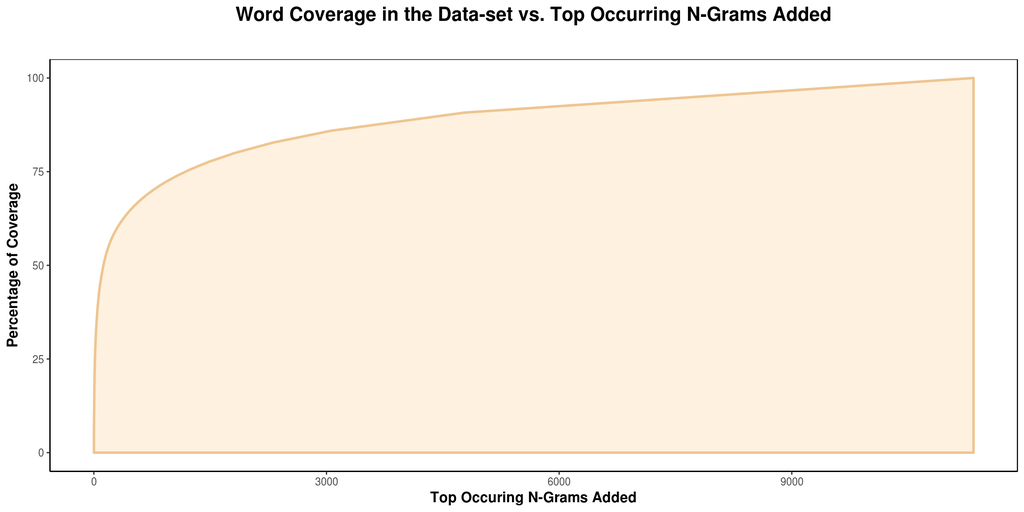

```r
ggplot(words_coverage, aes(x = words, y = coverage)) +
    geom_area(colour = "burlywood2", fill = "burlywood1", size = 1, alpha = 0.3) +
    ggtitle("Word Coverage in the Data-set vs. Top Occurring N-Grams Added") +
    xlab("Top Occuring N-Grams Added") +
    ylab("Percentage of Coverage") +
    theme(plot.title = element_text(size = 16, face = "bold",
                                    hjust = 0.5, margin = margin(b = 30, unit = "pt"))) +
    theme(axis.title.x = element_text(size = 12, face="bold")) +
    theme(axis.title.y = element_text(size = 12, face="bold")) +
    theme(panel.background = element_blank(), axis.line = element_line(colour = "black")) +
    theme(panel.border = element_rect(colour = "black", fill = NA, size = 0.5)) +
    theme(strip.background = element_rect(fill = alpha("burlywood3", 0.3), color = "black", size = 0.5))
```

This function plot that we have obtained experimentally from data is named [Zipf CDF](https://en.wikipedia.org/wiki/Zipf%27s_law) (Cumulative Distribution Function). It is a well known fact that the distribution of words in natural languages follows the distribution described by this function.

Now we need to know what’s the minimum number of top words added to achieve 50% and 90% coverage:

```r
number_ngrams_for_50_percent_coverage <- min(words_coverage[words_coverage$coverage > 50, ]$words)
number_ngrams_for_50_percent_coverage
```

```
## [1] 124
```

```r
number_ngrams_for_90_percent_coverage <- min(words_coverage[words_coverage$coverage > 90, ]$words)
number_ngrams_for_90_percent_coverage
```

```
## [1] 4512
```

```r
tail(words_coverage, n = 1)[, 2]
```

```
## [1] 11343
```

According with these computations, we would need 124 words to achieve 50% coverage (that is, that’s the minimum number of top words added that would represent half of the words present in the data) and 4512 words to achieve 90%.

### Language Detection

#### Language Detection Using TextCat

How about estimating the number of words in the data that are actually written in the English language:

```r
one_ngrams_dt <- data.table(one_grams)
```

I’m using data tables due to performance. Much faster than using `sapply()` on data frames.

The R package [textcat](https://www.rdocumentation.org/packages/textcat/versions/1.0-4) uses machine learning to detect several languages:

```r
names(TC_byte_profiles)
```

```
##  [1] "afrikaans"           "albanian"            "amharic-utf"
##  [4] "arabic-iso8859_6"    "arabic-windows1256"  "armenian"
##  [7] "basque"              "belarus-windows1251" "bosnian"
## [10] "breton"              "bulgarian-iso8859_5" "catalan"
## [13] "chinese-big5"        "chinese-gb2312"      "croatian-ascii"
## [16] "czech-iso8859_2"     "danish"              "dutch"
## [19] "english"             "esperanto"           "estonian"
## [22] "finnish"             "french"              "frisian"
## [25] "georgian"            "german"              "greek-iso8859-7"
## [28] "hebrew-iso8859_8"    "hindi"               "hungarian"
## [31] "icelandic"           "indonesian"          "irish"
## [34] "italian"             "japanese-euc_jp"     "japanese-shift_jis"
## [37] "korean"              "latin"               "latvian"
## [40] "lithuanian"          "malay"               "manx"
## [43] "marathi"             "middle_frisian"      "mingo"
## [46] "nepali"              "norwegian"           "persian"
## [49] "polish"              "portuguese"          "quechua"
## [52] "romanian"            "rumantsch"           "russian-iso8859_5"
## [55] "russian-koi8_r"      "russian-windows1251" "sanskrit"
## [58] "scots"               "scots_gaelic"        "serbian-ascii"
## [61] "slovak-ascii"        "slovak-windows1250"  "slovenian-ascii"
## [64] "slovenian-iso8859_2" "spanish"             "swahili"
## [67] "swedish"             "tagalog"             "tamil"
## [70] "thai"                "turkish"             "ukrainian-koi8_r"
## [73] "vietnamese"          "welsh"               "yiddish-utf"
```

This package is quite flexible and allows detection using several different profiles. Here’s another one:

```r
names(ECIMCI_profiles)
```

```
##  [1] "bg"      "bs"      "cs"      "da"      "de"      "el"      "en"
##  [8] "es"      "fi"      "fr"      "hr"      "hu"      "it"      "la"
## [15] "nl"      "no"      "pl"      "pt"      "ro"      "ru"      "sk"
## [22] "sl"      "sq"      "sr-Cyrl" "sr-Latn" "sv"
```

You may also exclude languages from a particular profile:

```r
languages <- c("english", "german", "finnish", "russian-iso8859_5",   "russian-koi8_r", "russian-windows1251")
sub_tc_byte_profiles <- TC_byte_profiles[names(TC_byte_profiles) %in% languages]
names(sub_tc_byte_profiles)
```

```
## [1] "english"             "finnish"             "german"
## [4] "russian-iso8859_5"   "russian-koi8_r"      "russian-windows1251"
```

You may then use these profiles for detection:

```r
language_dt <- one_ngrams_dt[, language := textcat(ngram, p = sub_tc_byte_profiles)]
language_aggregated_dt <- language_dt[, sum(frequency), by = language]
names(language_aggregated_dt) <- c("language", "frequency")
language_aggregated_dt <- language_aggregated_dt[, percentage := round(frequency / sum(language_dt[, 2]) * 100, 2)]
as.data.frame(language_aggregated_dt)
```

| language | frequency | percentage |
| --- | --- | --- |
| english | 53605 | 75.49 |
| finnish | 7604 | 10.71 |
| german | 9767 | 13.75 |
| NA | 34 | 0.05 |
| russian-iso8859_5 | 1 | 0.00 |
| russian-windows1251 | 1 | 0.00 |

Looking at the classification for each word, it seems like textcat’s accuracy leaves to desire quite a bit:

```r
language_dt[1:10, ]
```

| ngram | frequency | language |
| --- | --- | --- |
| the | 3392 | english |
| to | 1877 | english |
| and | 1698 | english |
| a | 1571 | english |
| i | 1431 | finnish |
| of | 1386 | english |
| in | 1164 | english |
| s | 826 | german |
| it | 804 | english |
| for | 775 | english |

Thus, I decided to experiment with a different method, which follows in the next section.

#### Language Detection Using WordNet

The following function uses the wordnet package to determine if a word belongs to the English language:

```r
synonyms_found <- function(word, pos)
    length(synonyms(word, pos)) > 0

vectorized_synonyms <- function(words, pos)
    sapply(words, synonyms_found, pos = pos)

stopWords <- stopwords("english")

is_stop_word <- function(input_word)
  input_word %in% stopWords

is_english_word <- function(input_word) {
    test_adjective <- vectorized_synonyms(word = singularize(input_word), "ADJECTIVE")
    test_adverb <- vectorized_synonyms(word = singularize(input_word), "ADVERB")
    test_noun <- vectorized_synonyms(word = singularize(input_word), "NOUN")
    test_verb <- vectorized_synonyms(word = singularize(input_word), "VERB")
    test_adjective | test_adverb | test_noun | test_verb | is_stop_word(input_word)
}

is_english_dt <- one_ngrams_dt[, is_english := is_english_word(ngram)]
is_english_aggregated_dt <- is_english_dt[, sum(frequency), by = is_english]
names(is_english_aggregated_dt) <- c("is_english", "frequency")
is_english_aggregated_dt <- is_english_aggregated_dt[, percentage := round(frequency / sum(language_dt[, 2]) * 100, 2)]
as.data.frame(is_english_aggregated_dt)
```

| is_english | frequency | percentage |
| --- | --- | --- |
| TRUE | 64764 | 91.2 |
| FALSE | 6248 | 8.8 |

These numbers seem more reasonable, as well as the classification for each word:

```r
as.data.frame(is_english_dt[1:12, ])
```

| ngram | frequency | language | is_english |
| --- | --- | --- | --- |
| the | 3392 | english | TRUE |
| to | 1877 | english | TRUE |
| and | 1698 | english | TRUE |
| a | 1571 | english | TRUE |
| i | 1431 | finnish | TRUE |
| of | 1386 | english | TRUE |
| in | 1164 | english | TRUE |
| s | 826 | german | FALSE |
| it | 804 | english | TRUE |
| for | 775 | english | TRUE |
| that | 759 | english | TRUE |
| is | 727 | english | TRUE |

## Prediction Model

0.1% of the data was enough to find patterns in the data, but to generate the model, I’m going to increase the amonunt of data:

```r
create_sample_files("./data/final/en_US", "./data/samples", 0.002, 0.3)
corpus_without_curse_words <- create_corpus("./data/samples/training")
```

### Unknown Words

```r
add_unknown_words <- function(corpus) {
    document_term_matrix <-
        DocumentTermMatrix(corpus,
                           control = list(tokenize = function(x) NGramTokenizer(x, Weka_control(min = 1, max = 1)),
                           wordLengths=c(1, Inf)))
    words <- names(colSums(as.matrix(document_term_matrix)))

    counter <- 0
    percentage_counter <- 0
    percentage_complete <- 0
    for(word in words) {

        document_index <- which.max(tm_index(corpus, FUN = function(x) any(grep(paste0("\\b", word,"\\b"), content(x)))))
        line_index <- which.max(grepl(paste0("\\b", word, "\\b"), content(corpus[[document_index]])))
        content(corpus[[document_index]])[line_index] <-
            sub(paste0("\\b", word, "\\b"), "<unknown>",
                content(corpus[[document_index]])[line_index])

        counter <- counter + 1
        percentage_counter <- round(counter * 100 / length(words))
        if(percentage_counter > percentage_complete & percentage_counter < 100) {
            percentage_complete <- percentage_counter
            print(paste0(percentage_complete, "% complete."))
        }
    }
    print("complete.")
    corpus
}

corpus_without_curse_words <- add_unknown_words(corpus_without_curse_words)
```

[output not shown]

[output cut: 85 more lines]

The requirement document include the following items:

- Build basic n-gram model - using the exploratory analysis you performed, build a basic n-gram model for predicting the next word based on the previous 1, 2, or 3 words.
- Build a model to handle unseen n-grams - in some cases people will want to type a combination of words that does not appear in the corpora. Build a model to handle cases where a particular n-gram isn’t observed.

These requirements basically describe [Katz’s Back-off](https://en.wikipedia.org/wiki/Katz%27s_back-off_model), thus that will be the solution adopted. I don’t think that makes any sense to implement a maximum likelihood estimation model with additive smoothing even for comparison. This has been done repeatedly in NLP literature.

### Katz’s Back-off

The best resource I could find for Katz’s Back-off is from the paper [“An Empirical Study of Smoothing Techniques for Language Modeling”](http://www.aclweb.org/anthology/P96-1041), from which I have obtained the formulas used in this section.

That’s a good complement to Katz’s original paper, [“Estimation of Probabilities from Sparse Data for the Language Model Component of a Speech Recognizer”](https://pdfs.semanticscholar.org/969a/9ec5f24dabcfb9c70c7ee04625075a6c0a98.pdf).

$$\begin{align}
& P_{bo} (w_i \mid w_{i-n+1} \cdots w_{i-1}) \\[4pt]
= {} & \begin{cases}
d_{w_{i-n+1} \cdots w_{i}} \dfrac{C(w_{i-n+1} \cdots w_{i-1}w_{i})}{C(w_{i-n+1} \cdots w_{i-1})} & \text{if } C(w_{i-n+1} \cdots w_i) > k \\[10pt]
\alpha_{w_{i-n+1} \cdots w_{i-1}} P_{bo}(w_i \mid w_{i-n+2} \cdots w_{i-1}) & \text{otherwise}
\end{cases}
\end{align}$$

$$\alpha_{w_{i-n+1} \cdots w_{i -1}} = \frac{\beta_{w_{i-n+1} \cdots w_{i -1}}} {1 - \sum_{ \{ w_i : C(w_{i-n+1} \cdots w_{i}) \gt k \} } P_{bo}(w_i \mid w_{i-n+2} \cdots w_{i-1})}$$

Where $P_{ML}$ is the maximum likelihood estimator for the conditional probability.

$$\beta_{w_{i-n+1} \cdots w_{i -1}} = 1 - \sum_{ \{w_i : C(w_{i-n+1} \cdots w_{i}) > k \} } d_{w_{i-n+1} \cdots w_{i}} \frac{C(w_{i-n+1}\cdots w_{i-1} w_{i})}{C(w_{i-n+1} \cdots w_{i-1})}$$

#### Examples of Katz Back-off

After consulting multiple resources over the web, I couldn’t find a clear example of its use. For these reason, I have decided to put a full example of how to compute the probabilities for this model in this notebook (for future reference).

I’m going to show the calculation steps for the example: $P_{bo}(\text{"word"}|\text{"bird is the"})$.

##### Example Without Back-off

Let’s start with the simplest case, suppose further that $C(\text{"bird is the word"}) > k$. In the case:

$$P_{bo}(\text{"word"}|\text{"is the word"}) = d_{\text{"bird is the word"}} \frac{C({\text{"bird is the word"}})}{C({\text{"bird is the"}})}$$

$d_{\text{"bird is the word"}}$ is computed using [Good-Turing frequency estimation](https://en.wikipedia.org/wiki/Good%E2%80%93Turing_frequency_estimation):

$$d_{\text{"bird is the word"}} = \frac{(C(\text{"bird is the word"}) + 1)}{C(\text{"bird is the word"})} \times \frac{n_{C(\text{"bird is the word"}) + 1}}{n_{C(\text{"bird is the word"})}}$$

Where $n_x$ is the number of n-grams that occured in the corpus exactly $x$ times.

##### Example With a Single Back-off

Let’s start with the simplest case, suppose further that $C(\text{"bird is the word"}) \leq k$. In the case:

$$P_{bo}(\text{"word"}|\text{"is the word"}) = \alpha_{\text{"bird is the"}} P_{bo}(\text{"word"} | \text{"is the"})$$

$$\alpha_{\text{"bird is the"}} = \frac{\beta_{\text{"bird is the"}}}{\sum_{\{x:C(\text{"bird is the x"}) \leq k\}} P_{bo}(\text{"x"} | \text{"is the"})}$$

Finally for $\beta$:

$$\beta_{\text{"bird is the"}} = 1 - \sum_{\{x:C(\text{"is the x"}) \gt k\}}d_{\text{"is the x"}} \frac{C(\text{"is the x"})}{C(\text{"is the"})}$$

Let’s start with the discount by using Good-Turing’s method:

$$Count_{Good-Turing} = (Count + 1) \frac{n_{(Count + 1)}}{n_{Count}}$$

Where $n_x$ is the number of n-grams observed $x$ times or “the frequency of words with frequency $x$”.

The Good-Turing method tries to estimate counts (frequency) of missing observations from counts of different existent observations.

$$Discount = \frac{Count_{Good-Turing}}{Count}$$

You will find this formula on Katz’s original paper (formula (3)).

#### Katz Back-off Implementation

##### Map of Frequencies

I’m going to need a sub-set of n-grams of different sizes. I’m creating a function to generate an amalgate of n-grams with different sizes from the individual n-gram data-sets:

```r
create_frequencies <- function(corpus, min_count) {
    one_to_four_gram_tokenizer <- function(x)
        NGramTokenizer(x, Weka_control(min = 1, max = 8))
    document_term_matrix <- DocumentTermMatrix(corpus,
                                               control = list(tokenize = one_to_four_gram_tokenizer,
                                                              wordLengths=c(1, Inf)))
    ngrams <- create_ngrams_data_frame(as.matrix(document_term_matrix))
    ngrams$frequency <- sapply(ngrams$frequency, function(x) x - 1)
    ngrams <- rbind(ngrams, data.frame(ngram = "<UNKNOWN>", frequency = nrow(ngrams)))
    data.table(subset(ngrams, frequency > min_count))
}

frequencies_dt <- create_frequencies(corpus_without_curse_words, 0)
sample_n(frequencies_dt, 12)
```

| ngram | frequency |
| --- | --- |
| the truck | 2 |
| something | 4 |
| from what | 2 |
| the eighth | 2 |
| intention to | 1 |
| approved by both houses of the | 1 |
| movement | 1 |
| don t feel like | 2 |
| we were | 2 |
| the water | 4 |
| today went | 1 |
| police chief | 1 |

I’m going to pre-process the table of frequencies to speed-up computation by creating a column for “history” (tokens preceding the last token) and “word” (last token):

```r
extract_history <- function(ngram){
    ifelse(length(ngram) > 1,
           paste(ngram[1:(length(ngram)-1)], collapse = " "),
           ""
    )
}

extract_word <- function(ngram) paste(ngram[length(ngram)], collapse = " ")

build_processed_ngram_frequencies <- function(frequencies_dt) {
    data <- as.data.frame(frequencies_dt)
    data$ngram <- strsplit(data$ngram, split = " |'")
    data$ngram_length <- sapply(data$ngram, length)
    data$history <- sapply(data$ngram, extract_history)
    data$word <- sapply(data$ngram, extract_word)
    data$ngram <- sapply(data$ngram, paste, collapse = " ")
    data.table(data)
}

ngram_frequencies_dt <- build_processed_ngram_frequencies(frequencies_dt)
as.data.frame(ngram_frequencies_dt[ngram_length > 1, ][order(-frequency), ][1:50, ])
```

| ngram | frequency | ngram_length | history | word |
| --- | --- | --- | --- | --- |
|  | 3032 | 2 |  |  |
| the | 1459 | 2 | the |  |
| and | 878 | 2 |  | and |
|  | 706 | 3 |  |  |
| a | 700 | 2 | a |  |
| and | 633 | 2 | and |  |
| of the | 616 | 2 | of | the |
| in the | 570 | 2 | in | the |
| the | 502 | 2 |  | the |
| to | 484 | 2 |  | to |
| of | 483 | 2 |  | of |
| to | 465 | 2 | to |  |
| of | 434 | 2 | of |  |
| in | 429 | 2 |  | in |
| it s | 387 | 2 | it | s |
| i m | 311 | 2 | i | m |
| to the | 296 | 2 | to | the |
| the | 289 | 3 | the |  |
| on the | 285 | 2 | on | the |
| for the | 282 | 2 | for | the |
| for | 280 | 2 |  | for |
| and | 276 | 3 | and |  |
|  | 261 | 4 |  |  |
| i | 246 | 2 |  | i |
| in | 240 | 2 | in |  |
| on | 231 | 2 |  | on |
| is | 230 | 2 |  | is |
| s | 230 | 2 |  | s |
| don t | 225 | 2 | don | t |
| that | 216 | 2 |  | that |
| s | 214 | 2 | s |  |
| a | 211 | 2 |  | a |
| at the | 208 | 2 | at | the |
| to be | 204 | 2 | to | be |
| with | 202 | 2 |  | with |
| and | 201 | 3 |  | and |
| in a | 164 | 2 | in | a |
| for | 161 | 2 | for |  |
| it | 160 | 2 |  | it |
| my | 154 | 2 | my |  |
| and the | 152 | 2 | and | the |
| with the | 152 | 2 | with | the |
| of the | 150 | 3 | of the |  |
| the | 150 | 3 | the |  |
| at | 148 | 2 |  | at |
| a | 142 | 3 | a |  |
| is a | 142 | 2 | is | a |
| is | 142 | 2 | is |  |
| that | 142 | 2 | that |  |
| and i | 140 | 2 | and | i |

Computing probabilities for the model will require counts for histories as well, so let’s create a data table specifically for this purpose:

```r
history_frequencies_dt <-
    ngram_frequencies_dt[, c("history", "frequency")][, lapply(.SD, sum), by = list(history)]

as.data.frame(history_frequencies_dt[order(-frequency), ][1:50])
```

| history | frequency |
| --- | --- |
|  | 883811 |
|  | 13559 |
| the | 4665 |
| to | 2931 |
| i | 2478 |
| a | 2219 |
| and | 2176 |
|  | 2151 |
| of | 1941 |
| in | 1718 |
| it | 1192 |
| for | 1089 |
| that | 1034 |
| you | 1021 |
| is | 998 |
| s | 917 |
| the | 895 |
| on | 861 |
| with | 711 |
| at | 616 |
| he | 539 |
| have | 531 |
| was | 524 |
| and | 523 |
| t | 516 |
| my | 494 |
| as | 490 |
|  | 486 |
| this | 478 |
| be | 469 |
| we | 469 |
| but | 468 |
| are | 413 |
| a | 371 |
| from | 355 |
| and | 347 |
| if | 346 |
| not | 334 |
| they | 329 |
| will | 325 |
| so | 323 |
| can | 318 |
| me | 315 |
| of | 304 |
| to | 304 |
| in the | 289 |
| when | 288 |
| in | 287 |
| of the | 286 |
| all | 286 |

##### Good-Turing Estimation

The first step for applying the method is obtaning the frequency of sizes of observations:

```r
frequencies_of_frequencies <- table(ngram_frequencies_dt$frequency)
frequencies_of_frequencies
```

```
##
##      1      2      3      4      5      6      7      8      9     10
##  16081   5190   2611   1615   1021    746    562    423    333    246
##     11     12     13     14     15     16     17     18     19     20
##    226    190    167    134    141    123    104     78     81     66
##     21     22     23     24     25     26     27     28     29     30
##     64     59     62     50     52     37     42     24     40     33
##     31     32     33     34     35     36     37     38     39     40
##     18     33     26     32     23     24     21     21     15     18
##     41     42     43     44     45     46     47     48     49     50
##     15     21     12     14     15     12      9      9     24     10
##     51     52     53     54     55     56     57     58     59     60
##      7     13      9      6     13      7      9      6      4      8
##     61     62     63     64     65     66     67     68     69     70
##      8      6      5      8      8     10      3      6      1      4
```

[output cut: 40 more lines]

Applying the Good-Turing formula:

```r
frequency_of_frequency <- function(frequency, frequencies_of_frequencies)
    try_default(frequencies_of_frequencies[[toString(frequency)]], 1, quiet = TRUE)

discount <- function(count, frequencies_of_frequencies) {
    good_turing_count <- (count + 1) *
        frequency_of_frequency(count + 1, frequencies_of_frequencies) /
        frequency_of_frequency(count, frequencies_of_frequencies)
    computed_discount <- good_turing_count / count
    ifelse(computed_discount < 1, computed_discount, 1)
}

discount(1, frequencies_of_frequencies)
```

```
## [1] 0.6454822
```

The following chunk implements all formulas required to compute the Katz’s probability ($P_{bo}$ in the formula):

```r
count_ngram <- function(word_value, history_value, ngram_frequencies_dt) {
    count <- ngram_frequencies_dt[word == word_value & history == history_value, ]$frequency
    ifelse(length(count) > 0, count, 1)
}

count_history <- function(history_value, history_frequencies_dt) {
    count <- history_frequencies_dt[history == history_value, ]$frequency
    ifelse(length(count) > 0, count, 1)
}

total_words <- sum(ngram_frequencies_dt[ngram_length == 1, ]$frequency)

count_ngram("t", "don", ngram_frequencies_dt)
```

```
## [1] 225
```

```r
count_history("don", history_frequencies_dt)
```

```
## [1] 226
```

I’m using a data table due to its better performance.

##### Back-off

```r
backoff_history <- function(history) {
    history_words <- strsplit(history, split = " |'")
    ifelse(
        length(history_words[[1]]) > 1,
        trimws(paste(backoff_history_words <- history_words[[1]][2:length(history_words[[1]])], collapse = " ")),
        ""
    )
}

backoff_history("bird is the word")
```

```
## [1] "is the word"
```

```r
backoff_history(backoff_history("bird is the word"))
```

```
## [1] "the word"
```

```r
backoff_history("")
```

```
## [1] ""
```

##### Katz’s Beta

```r
katz_beta <- function(history_value, k,
                      ngram_frequencies_dt,
                      history_frequencies_dt,
                      frequencies_of_frequencies) {

    counts <- ngram_frequencies_dt[history == history_value & frequency > k, ]$frequency
    history_count <- count_history(history_value, history_frequencies_dt)
    1 - ifelse(length(counts) > 0,
               sum(
                   sapply(counts,
                          function(x) discount(x, frequencies_of_frequencies) * x / history_count
                   )
               ),
               0
    )
}

memoized_katz_beta <- addMemoization(katz_beta)

memoized_katz_beta("didn", 5,
                   ngram_frequencies_dt,
                   history_frequencies_dt,
                   frequencies_of_frequencies)
```

```
## [1] 0.4946237
```

##### Katz’s Alpha

```r
katz_alpha_summation <- function(history_value, k,
                                 ngram_frequencies_dt,
                                 history_frequencies_dt,
                                 frequencies_of_frequencies) {
    words <- ngram_frequencies_dt[history == history_value & frequency <= k, ]$word
    ifelse(length(words) > 0,
           sum(
               sapply(words,
                      katz_probability,
                      history = backoff_history(history_value),
                      k = k,
                      ngram_frequencies_dt = ngram_frequencies_dt,
                      history_frequencies_dt = history_frequencies_dt,
                      frequencies_of_frequencies = frequencies_of_frequencies
               )
           ),
           0
    )
}

memoized_katz_alpha_summation <- addMemoization(katz_alpha_summation)

katz_alpha <- function(history, k,
                       ngram_frequencies_dt,
                       history_frequencies_dt,
                       frequencies_of_frequencies) {

    computed_katz_alpha_summation <- memoized_katz_alpha_summation(history, k,
                                                                   ngram_frequencies_dt,
                                                                   history_frequencies_dt,
                                                                   frequencies_of_frequencies
    )

    computed_katz_beta <- memoized_katz_beta(history, k,
                                              ngram_frequencies_dt,
                                              history_frequencies_dt,
                                              frequencies_of_frequencies
    )

    computed_katz_alpha <- ifelse(computed_katz_alpha_summation != 0,
                                  computed_katz_beta / computed_katz_alpha_summation,
                                  1)
    ifelse(computed_katz_alpha < 1, computed_katz_alpha, 1)
}

memoized_katz_alpha <- addMemoization(katz_alpha)

katz_probability <- function(word, history, k,
                             ngram_frequencies_dt,
                             history_frequencies_dt,
                             frequencies_of_frequencies,
                             verbose = FALSE) {
    if(verbose) print(paste0("katz_probability(word: [", word, "], history: [", history, "])..."))

    word_with_history <- trimws(paste(history, word))
    count <- count_ngram(word, history, ngram_frequencies_dt)

    probability <- ifelse(
        history == "",
        discount(count, frequencies_of_frequencies) * count / total_words,
        ifelse(count > k,
               discount(count, frequencies_of_frequencies) * count / count_history(history, ngram_frequencies_dt),
               memoized_katz_alpha(history, k, ngram_frequencies_dt, history_frequencies_dt, frequencies_of_frequencies) *
                   katz_probability(word, backoff_history(history), k,
                                    ngram_frequencies_dt,
                                    history_frequencies_dt,
                                    frequencies_of_frequencies,
                                    verbose = verbose)
        )
    )

    if(verbose) print(paste0("katz_probability(word: [", word, "], history: [", history, "]) = ", probability))
    probability
}

katz_alpha_summation("didn", 5, ngram_frequencies_dt, history_frequencies_dt, frequencies_of_frequencies)
```

```
## [1] 0
```

```r
katz_alpha("didn", 5, ngram_frequencies_dt, history_frequencies_dt, frequencies_of_frequencies)
```

```
## [1] 1
```

```r
katz_probability("s", "didn", 5, ngram_frequencies_dt, history_frequencies_dt, frequencies_of_frequencies)
```

```
## [1] 0.001827314
```

Given that $\beta_i$ and $\sum_{i} \alpha_i$ are probabilities, they need to be smaller or equal to one. In practice though, I’m working with estimates obtained from the text corpus and estimations will be as good as our data, thus the calculations might result in values greater than one.

Another issue is that computers introduce rounding errors. For this reason, I’m limiting the value of $\alpha_i$ and $\beta_i$ to one, that is, if the estimate $\alpha_i$ and $\beta_i$ exceeds one, I assume they are actually equal to one.

#### Computing a Markov Chain Trainsition Matrix

Now that I can compute Katz’s probabilities, I will create a transition matrix, which is a representation of a [Markov Chain](https://en.wikipedia.org/wiki/Markov_chain):

```r
create_transition_matrix <- function(k,
                                     ngram_frequencies_dt,
                                     history_frequencies_dt,
                                     frequencies_of_frequencies,
                                     min_count = 3, verbose = FALSE) {

    prediction_data <- ngram_frequencies_dt[ngram_length > 1 & frequency > min_count, ]

    histories <- unique(c("", prediction_data$history))
    print(paste0("history size: ", length(histories)))

    words <- unique(prediction_data$word)
    print(paste0("word size: ", length(words)))

    transition_matrix <- matrix(NA, length(histories), length(words))
    rownames(transition_matrix) <- histories
    colnames(transition_matrix) <- words

    percentage_complete <- 0
    percentage_counter <- 0
    for(i in 1:length(histories)){
        for(j in 1:length(words)){
            transition_matrix[i, j] <- katz_probability(words[[j]],
                                                        histories[[i]],
                                                        k,
                                                        ngram_frequencies_dt,
                                                        history_frequencies_dt,
                                                        frequencies_of_frequencies,
                                                        verbose = verbose)
        }
        percentage_complete <- round((i * length(words) + j + 1) / (length(histories) * length(words)) * 100)
        if(percentage_complete > percentage_counter & percentage_complete < 100) {
            percentage_counter <- percentage_complete
            print(paste0(percentage_counter, "% complete."))
        }
    }
    print("complete.")
    transition_matrix
}

model <- create_transition_matrix(5,
                                  ngram_frequencies_dt,
                                  history_frequencies_dt,
                                  frequencies_of_frequencies)
```

[output not shown]

[output cut: 87 more lines]

```r
str(model)
```

```
##  num [1:1519, 1:738] 0.0196 1 1 1 1 ...
##  - attr(*, "dimnames")=List of 2
##   ..$ : chr [1:1519] "" "<unknown>" "the" "<unknown> <unknown>" ...
##   ..$ : chr [1:738] "<unknown>" "and" "the" "to" ...
```

To optimize the Katz’s probability calculation, I have ran the function that creates the transition matrix with profililng:

```r
Rprof("./output.txt")
model <- create_transition_matrix(5,
                                  ngram_frequencies_dt,
                                  history_frequencies_dt,
                                  frequencies_of_frequencies)
summaryRprof("./output.txt")
```

I have disabled this chunk given that I won’t needed any longer, but I’m keeping it for future reference.

Let’s do a sanity check:

```r
which(is.na(model), arr.ind = TRUE)
```

```
##      row col
```

All rows are in the range value for probabilities and there aren’t any NAs.

Given that I’m going to ultimately load the model into memory in the keyboard typing prediction app and that shinyapps.io has a limitation (for the free account) of 1GB, let’s also take a look at the model’s size

```r
object.size(model)
```

```
## 9103992 bytes
```

### Making Predictions

Here are the history words supported by our toy model:

```r
rownames(model)
```

```
##    [1] ""
##    [2] "<unknown>"
##    [3] "the"
##    [4] "<unknown> <unknown>"
##    [5] "a"
##    [6] "and"
##    [7] "of"
##    [8] "in"
##    [9] "to"
##   [10] "it"
##   [11] "i"
##   [12] "the <unknown>"
##   [13] "on"
##   [14] "for"
##   [15] "<unknown> and"
```

[output cut: 1504 more lines]

As well as the words supported:

```r
colnames(model)
```

```
##   [1] "<unknown>"   "and"         "the"         "to"          "of"
##   [6] "in"          "s"           "m"           "for"         "i"
##  [11] "on"          "is"          "t"           "that"        "a"
##  [16] "be"          "with"        "it"          "at"          "have"
##  [21] "but"         "said"        "or"          "you"         "am"
##  [26] "as"          "was"         "are"         "from"        "ve"
##  [31] "get"         "by"          "who"         "can"         "do"
##  [36] "think"       "see"         "been"        "he"          "lot"
##  [41] "don"         "my"          "first"       "has"         "this"
##  [46] "little"      "ll"          "love"        "had"         "same"
##  [51] "his"         "out"         "re"          "make"        "good"
##  [56] "will"        "few"         "go"          "up"          "we"
##  [61] "when"        "about"       "know"        "not"         "than"
##  [66] "great"       "other"       "so"          "new"         "into"
##  [71] "me"          "take"        "best"        "world"       "they"
```

[output cut: 133 more lines]

Let’s see if the predictions make sense:

```r
extract_words_from_history <- function(model) unique(
    unname(
        unlist(
            sapply(rownames(model), function(x) ifelse(x == "", x, strsplit(x, split = " ")))
        )
    )
)

build_top_suggestions <- function(model, history, word_row, n) {
    word_row["<unknown>"] <- NA
    top_suggestions_indexes <- head(order(word_row, decreasing = TRUE), n = n)
    top_suggestions <- colnames(model)[top_suggestions_indexes]
    names(top_suggestions) <- model[history, top_suggestions_indexes]
    top_suggestions
}

replace_unknown_words <-function(history, model) {
    words <- extract_words_from_history(model)
    if(history == "") return(history)
    history_words <- strsplit(history, split = " ")
    history_words <- sapply(history_words, function(x) ifelse(x %in% words, x, "<unknown>"))
    paste(history_words, collapse = " ")
}

suggestions <- function(model, history, n = 5) {
    history <- replace_unknown_words(history, model)
    history <- ifelse(history == "", 1, history)
    word_row <- try_default(model[history, ], c(), quiet = TRUE)
    if(length(word_row) > 0) build_top_suggestions(model, history, word_row, n)
    else suggestions(model, backoff_history(history), n = n)
}

suggestions(model, "don", n = 5)
```

```
##                    1  0.00167647372342927  0.00097059005040642
##                  "t"                "the"                 "to"
## 0.000851752697939423 0.000827781214823762
##                  "a"                "and"
```

```r
suggestions(model, "last")
```

```
##   0.739889705882353   0.727941176470588   0.647058823529412
##              "year"             "night"              "week"
##   0.155101718971771 0.00743824188655719
##             "month"               "the"
```

```r
suggestions(model, "next")
```

```
##   0.820820820820821   0.820820820820821 0.00743824188655719
##              "year"              "week"               "the"
## 0.00430635056590153 0.00377908851553104
##                "to"                 "a"
```

```r
suggestions(model, "live and I d", n = 20)
```

```
##     0.41041041041041    0.292969913613345  0.00743824188655719
##                 "be"               "love"                "the"
##  0.00430635056590153  0.00377908851553104  0.00367273093455501
##                 "to"                  "a"                "and"
##   0.0031929903565355  0.00310134180271574  0.00258199999773707
##                  "i"                 "of"                 "in"
##  0.00182731375825827    0.001759425940614  0.00171077300463561
##                  "s"                 "it"                "for"
##   0.0017085100773808  0.00165646275052019  0.00160215249640477
##               "that"                 "is"                "you"
##  0.00136115074376762  0.00114277826367855 0.000980978964959703
##                 "on"               "with"                 "my"
## 0.000934588956236118 0.000923274319962073
##                 "at"                "was"
```

The suggestions make sense, so it seems like I’m in good shape. In the next section, I’m going to evaluate how good our model is in a more quantitative manner.

### Model Perplexity

I’m going to use [perplexity](https://en.wikipedia.org/wiki/Perplexity) as a measure for model performance:

$$2^H = 2^{- \frac{1}{L - m +1} \sum_{l = m}^{L} log_2 P(w_i|w_{l - m + 1}^{l - 1})}$$

Where: $w_i$ is the test word sequence and $m$ is the N-Gram size. Given that $m + 1 \ll L$ and our model has N-Grams of multiple sizes, I’m going to ignore $m + 1$ in the denominator.

First I need a function to extract conditional probabilities from the model:

```r
model_probability <- function(model, word, history) {
    if(!(word %in% colnames(model))) word <- "<unknown>"
    if(history == "") history <- 1
    probability <- try_default(model[history, word], NA, quiet = TRUE)
    ifelse(is.na(probability),
           model_probability(model, word, backoff_history(history)),
           probability)
}

model_probability(model, "t", "didn")
```

```
## [1] 0.5053763
```

```r
model_probability(model, "<gibberish>", "didn")
```

```
## [1] 0.01963203
```

```r
model_probability(model, "back", "")
```

```
## [1] 0.0002398703
```

I’m going to sample again from the corpus and create a test corpus:

```r
test_corpus <- create_corpus("./data/samples/testing")

two_to_four_ngrams <- function(x)
  NGramTokenizer(x, Weka_control(min = 2, max = 4))

document_term_matrix <- DocumentTermMatrix(test_corpus,
                                           control = list(tokenize = two_to_four_ngrams,
                                                          wordLengths=c(1, Inf)))

test_data <- build_processed_ngram_frequencies(create_ngrams_data_frame(as.matrix(document_term_matrix)))
sample_n(test_data, 12)
```

| ngram | frequency | ngram_length | history | word |
| --- | --- | --- | --- | --- |
| only five are | 1 | 3 | only five | are |
| so that she could | 1 | 4 | so that she | could |
| this is not | 1 | 3 | this is | not |
| what product they | 1 | 3 | what product | they |
| you need a crow | 1 | 4 | you need a | crow |
| been excited by | 1 | 3 | been excited | by |
| florida enclave one general | 1 | 4 | florida enclave one | general |
| bcs poll | 1 | 2 | bcs | poll |
| jobs half the | 1 | 3 | jobs half | the |
| cb isaiah frey | 1 | 3 | cb isaiah | frey |
| for joining | 1 | 2 | for | joining |
| are high again for | 1 | 4 | are high again | for |

Here I calculate perplexity for different N-Gram sizes:

```r
entropy <- function(model, test_data, ngram_length) {
     probabilities <- mapply(function(word, history) model_probability(model = model, word, history),
                             test_data$word, test_data$history)
     -sum(log(probabilities, base = 2)) / length(probabilities)
}

ngram_perplexity <- function(ngram_length_value, model, test_data) {
    ngram_data <- test_data[ngram_length == ngram_length_value, ]
    2^(entropy(model, ngram_data, ngram_length_value))
}

perplexity <- function(ngram_range, model, test_data) {
    perplexities <- sapply(ngram_range,
                           ngram_perplexity,
                           model = model,
                           test_data = test_data
    )

    data.frame(ngram_size = ngram_range,
               perplexity = perplexities
    )
}

perplexity(2:4, model, test_data)
```

| ngram_size | perplexity |
| --- | --- |
| 2 | 166.61300 |
| 3 | 106.67844 |
| 4 | 98.60377 |

### Saving the Model to Disk

```r
save(model, file = "./data/model.rda")
```

```r
load(file = "./data/model.rda")
```

This command will load the object named `model` into the R environment.

## Results

### Exploratory Data Analysis

We have confirmed that the distribution of words follow some known theoretical properties by analyzing a randomly sampled sub-set of the available data. We are going to exploit such properties to build a prediction model for keyboard typing.

Regarding coverage, we would need 124 words to achieve 50% coverage and 4512 words to achieve 90%. Coverage follows a Zipf CDF, a known probability distribution function.

We could increase coverage by choosing words more aligned with the vocabulary of the specific user for which we want to do keyboard typing prediction. We could do that by the following means:

- Improving the data corpus by using text collected from each individual user (essentially each user would start with a standard corpus of text, which would improve as the user types new sentences). Each user would have its own particular corpus of text (or its own model, which would be updated over time). That could raise privacy concerns though, as we would be required to store at least bits of conversations and web browsing behavior. That wouldn’t be critical for public services such as blogs and twitter, but could be potentially a problem for news (we would need to keep track of articles the user has clicked on).
- Creating groups of users into different profiles (casual, business, scientific, etc) and respective models. A good approach would be to give the user the option of choosing a specific profile on the fly according with their current needs or commit to one when they sign-up for the service.

### Model Design

Our knowledge of the word coverage will allows us to limit the number of N-Grams utilized (we know we can cover 90% of the text with a fraction of the N-Grams).

The model is a Markov Chain transition matrix with size ($\text{Number of History N-Grams} \times \text{Number of Predicted Words}$). The matrix size is the number of parameters we need.

Given that we are estimating the probabilties from a text corpus and some history of words might not exist, resulting in zero probabilities, we are going to smooth probabilities. Specifically, we will use Katz’s Back-off and Good-Turing to estimate the probability of unobserved n-grams.

We will be using perplexity as a matric for evaluating our model’s performance.